# Praca domowa 2

Igor Zawada

## Dane

Dane wykorzystane w Pracy domowej 2 opisują wycenę nieruchmości. Każda obserwacja jest pewną nieruchmością, która posiada informacje takie jak powierzchnia, liczba pokoi, liczba łazienek i wiele więcj. Opis wszystkich kolumn w pliku `README.md`.

## Zadanie 1

Jak wygląda rozkład ceny nieruchomości w poszczególnych kodach pocztowych na przestrzeni lat? Rozważamy kody pocztowe, które mają więcej niż 280 posiadłości.

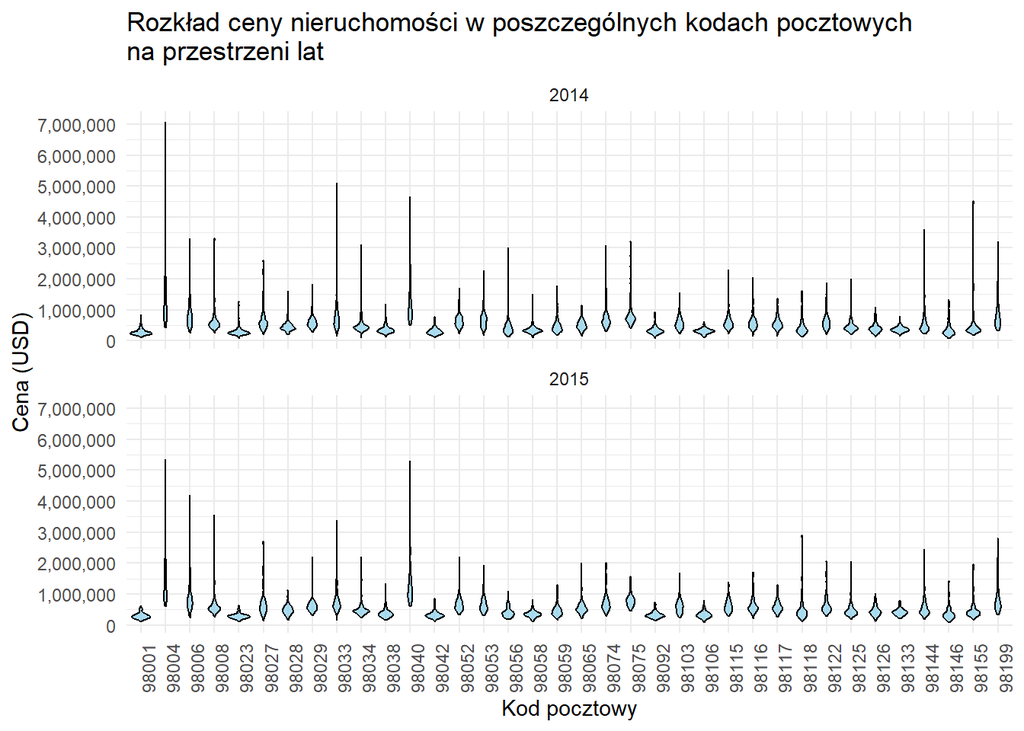

```r
df1 <- df %>%
  mutate(year = substr(date, 1, 4))

filtered_data <- df1 %>%
  group_by(zipcode) %>%
  filter(n() > 280) %>%
  ungroup()

ggplot(filtered_data, aes(x = as.factor(zipcode), y = price)) +
  geom_violin(fill = "skyblue", color = "black", alpha = 0.7) +
  scale_y_continuous(labels = function(x) format(x, big.mark = ",", scientific = FALSE), breaks = seq(0, max(df$price, na.rm = TRUE), by = 1000000))+
  facet_wrap(~ year, ncol = 1) +
  labs(title = "Rozkład ceny nieruchomości w poszczególnych kodach pocztowych\nna przestrzeni lat",
       x = "Kod pocztowy",
       y = "Cena (USD)") +
  theme_minimal() +
  theme(axis.text.x = element_text(angle = 90, hjust = 1))
```

**Komentarz: Tak prezentuje się rozkład względem kodów pocztowych. Rozdzielam wykres na lata, aby był bardziej czytelny**

## Zadanie 2

Czy jest różnica w rozkładzie ceny nierchomości od powierzchni mieszkalnej uwzględniając podział na nieruchomości z piwnicą i bez?

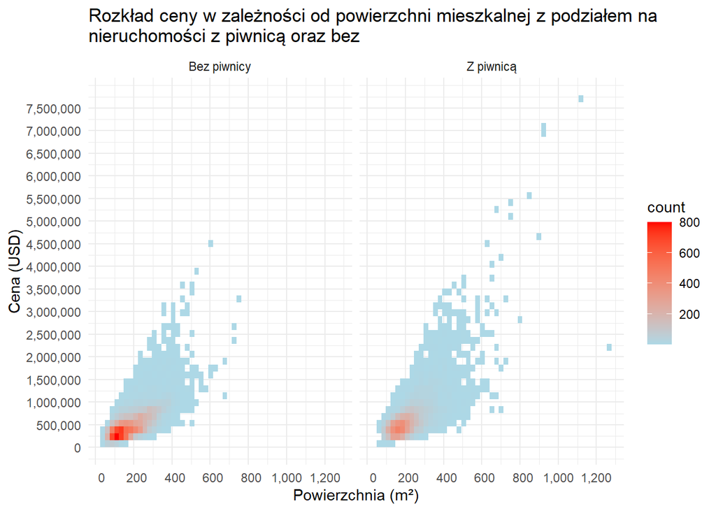

```r
# df %>%
#   mutate(sqft_living_m2 = sqft_living * 0.092903,
#     has_basement = ifelse(sqft_basement > 0, "posiada piwnicę", "nie posiada piwnicy")) %>%
#   ggplot(aes(x = sqft_living_m2, y = price, color = has_basement)) +
#   geom_point(alpha = 0.5) +
#   geom_smooth(method = "lm", se = FALSE, linetype = "dashed") +
#   scale_y_continuous(labels = function(x) format(x, big.mark = ",", scientific = FALSE), breaks = seq(0, max(df$price, na.rm = TRUE), by = 500000))+
#   scale_x_continuous(labels = function(x) format(x, big.mark = ",", scientific = FALSE), breaks = seq(0, max(df$sqft_living, na.rm = TRUE), by = 200))+
#   labs(title = "Rozkład ceny w zależności od powierzchni mieszkalnej z podziałem na nieruchomości z piwnicą oraz bez",
#        x = "Powierzchnia w metrach kwadratowych",
#        y = "Cena w USD",
#        color = "Basement") +
#   theme_minimal() +
#   scale_color_manual(values = c("posiada piwnicę" = "blue", "nie posiada piwnicy" = "red"))

#alternatywny wykres

df %>%
  mutate(
    sqft_living_m2 = sqft_living * 0.092903,
    has_basement = ifelse(sqft_basement > 0, "Z piwnicą", "Bez piwnicy")
  ) %>%
  ggplot(aes(x = sqft_living_m2, y = price)) +
  scale_y_continuous(labels = function(x) format(x, big.mark = ",", scientific = FALSE), breaks = seq(0, max(df$price, na.rm = TRUE), by = 500000))+
  scale_x_continuous(labels = function(x) format(x, big.mark = ",", scientific = FALSE), breaks = seq(0, max(df$sqft_living, na.rm = TRUE), by = 200))+
  geom_bin2d(bins = 50) +
  scale_fill_gradient(low = "lightblue", high = "red") +
  facet_wrap(~ has_basement) +
  labs(title = "Rozkład ceny w zależności od powierzchni mieszkalnej z podziałem na \nnieruchomości z piwnicą oraz bez",
       x = "Powierzchnia (m²)",
       y = "Cena (USD)") +
  theme_minimal()
```

## Zadanie 3

Jaka jest zależność pomiędzy jakością wykończenia nieruchomości a liczbą pięter?

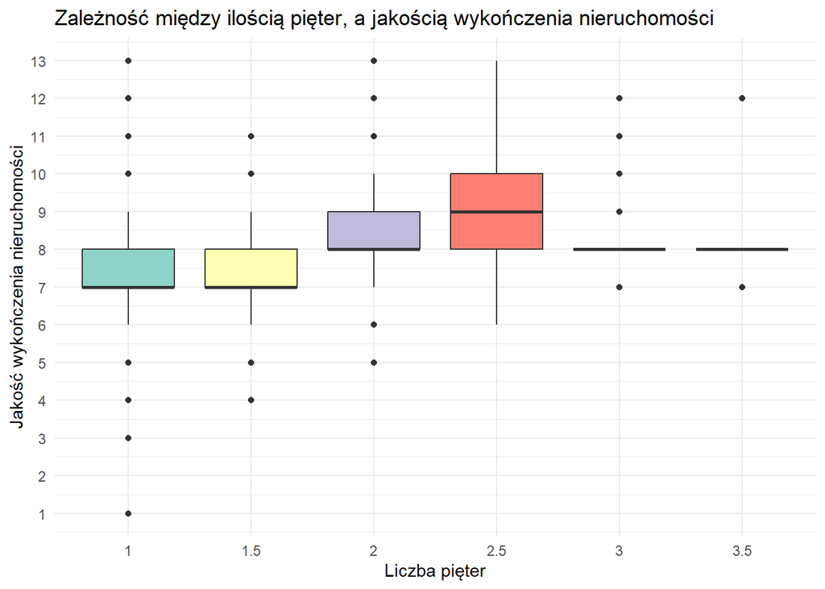

```r
df %>%
  ggplot(aes(x = as.factor(floors), y = grade, fill = as.factor(floors))) +
  geom_boxplot() +
  labs(title = "Zależność między ilością pięter, a jakością wykończenia nieruchomości",
       x = "Liczba pięter",
       y = "Jakość wykończenia nieruchomości") +
  scale_y_continuous(labels = function(x) format(x, big.mark = ",", scientific = FALSE), breaks = seq(0, max(df$grade, na.rm = TRUE), by = 1))+
  guides(fill = 'none') +
  theme_minimal() +
  scale_fill_brewer(palette = "Set3")
```

**Komentarz: Widzimy wzrost jakości wykończenia dla większej ilości pięter np patrząc na średnie dla kazdej ilosci pięter, kategoria nieruchomości z 3 lub 3.5 piętrami jest bardzo mało liczna, więc można powiedzieć, że jest widoczne powiązanie.**

## Zadanie 4

Jaka jest zależność między powierzchnią mieszkalną nieruchomości a powierzchnią gruntu w podziale na liczbę sypialni?

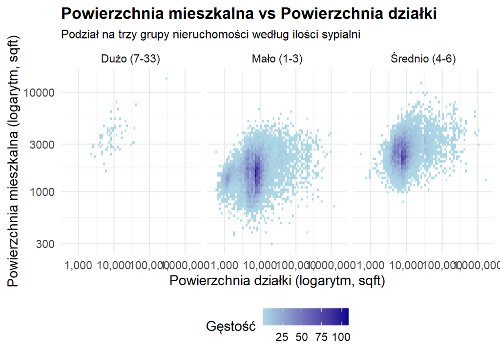

```r
df4 <- df %>%
  mutate(bedrooms_group = case_when(
    bedrooms <= 3 ~ "Mało (1-3)",
    bedrooms <= 6 ~ "Średnio (4-6)",
    bedrooms > 6  ~ "Dużo (7-33)"
  ))

# df4 %>%
#   ggplot(aes(x = sqft_lot, y = sqft_living, color = bedrooms_group)) +
#   geom_point(alpha = 0.3, size = 1) +
#   scale_color_manual(values = c("Mało (1-3)" = "purple", "Średnio (4-6)" = "green", "Dużo (7-33)" = "red")) +
#   scale_x_log10() +
#   scale_y_log10() +
#   labs(title = "Powierzchnia mieszkalna vs Powierzchnia działki",
#        x = "Powierzchnia działki (logarytm)",
#        y = "Powierzchnia mieszkalna (logarytm, sqft)",
#        color = "Liczba sypialni (grupy)") +
#   theme_minimal(base_size = 14) +
#   theme(legend.position = "bottom",
#         plot.title = element_text(face = "bold", size = 16),
#         plot.subtitle = element_text(size = 12))


df4 %>%
  ggplot(aes(x = sqft_lot, y = sqft_living)) +
  geom_bin2d(bins=70) +
  scale_fill_gradient(low = "lightblue", high = "darkblue", name = "Gęstość")+
  scale_x_log10(labels = comma) +
  scale_y_log10() +
  labs(title = "Powierzchnia mieszkalna vs Powierzchnia działki",
       subtitle = "Podział na trzy grupy nieruchomości według ilości sypialni",
       x = "Powierzchnia działki (logarytm, sqft)",
       y = "Powierzchnia mieszkalna (logarytm, sqft)") +
  facet_grid(~ bedrooms_group) +
  theme_minimal(base_size = 14) +
  theme(legend.position = "bottom",
        plot.title = element_text(face = "bold", size = 16),
        plot.subtitle = element_text(size = 12))
```

**Komentarz: Z wykresu wywnioskować można, że nieruchomości z dużą liczbą sypialni mają większą powierzchnie mieszkalną w stosunku do powierzchni działki niż nieruchomości ze średnią i małą liczbą sypialni.**

## Zadanie 5

Rozważmy tylko nieruchomości, które miały remont. W której dekadzie było najwięcej przeprowadzonych remontów? Czy w poszczególnych dekadach jest porównywalny procent nieruchmości dla każdej wartości miary jakości i wykończenia nieruchomości?

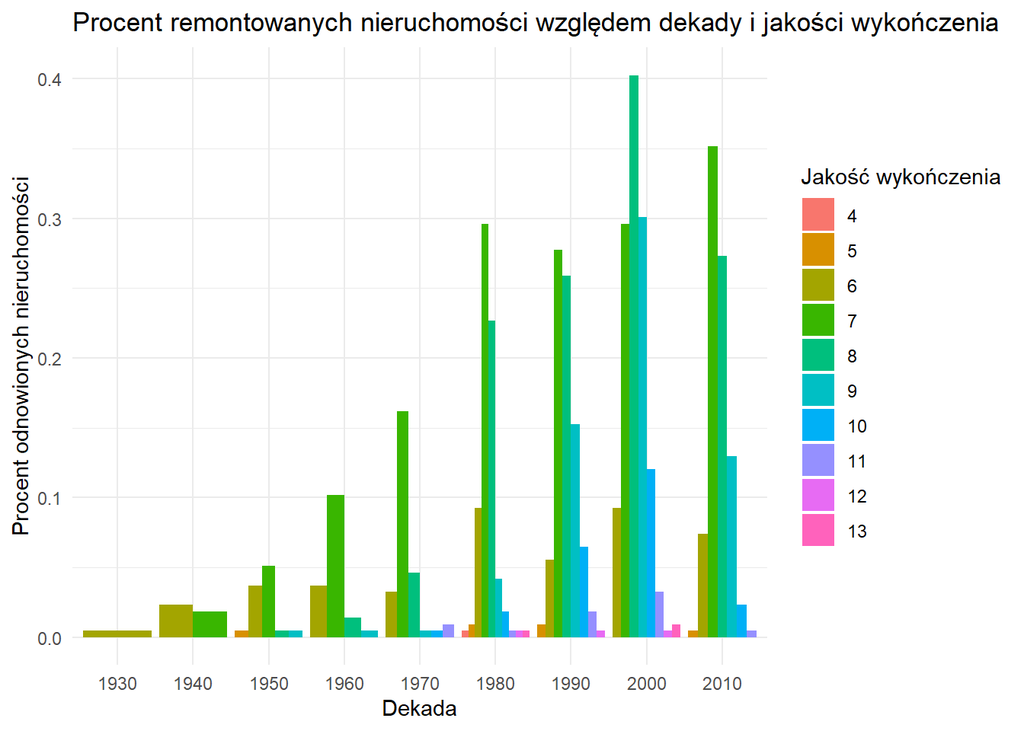

```r
df %>%
  filter(yr_renovated > 0) %>%
  mutate(decade = (yr_renovated %/% 10) * 10) %>%
  group_by(decade, grade) %>%
  summarise(count = n(),
            percentage = (count / nrow(df)) * 100) %>%
  ggplot(aes(x = factor(decade), y = percentage, fill = factor(grade))) +
  geom_bar(stat = "identity", position = "dodge") +
  labs(title = "Procent remontowanych nieruchomości względem dekady i jakości wykończenia",
       x = "Dekada",
       y = "Procent odnowionych nieruchomości",
       fill = "Jakość wykończenia") +
  theme_minimal()
```

```r
p <-  df %>%
  filter(yr_renovated > 0) %>%
  mutate(decade = (yr_renovated %/% 10) * 10) %>%
  group_by(decade) %>%
  summarise(count = n()) %>%
  arrange(desc(count))
```

**Komentarz: Najwięcej remontów wykonano w latach 2000-2010. Nie jest porównywalny procent dla każdej miary jakości, gdyż widzimy, że nieruchomości o mierze jakości 7-8 miały procentowo częsciej remonty.**

## Zadanie 6

Jak prezentuje się wartość minimalna, średnia i maksymalna ceny nieruchmości w podziele na rok budowy nieruchomości.

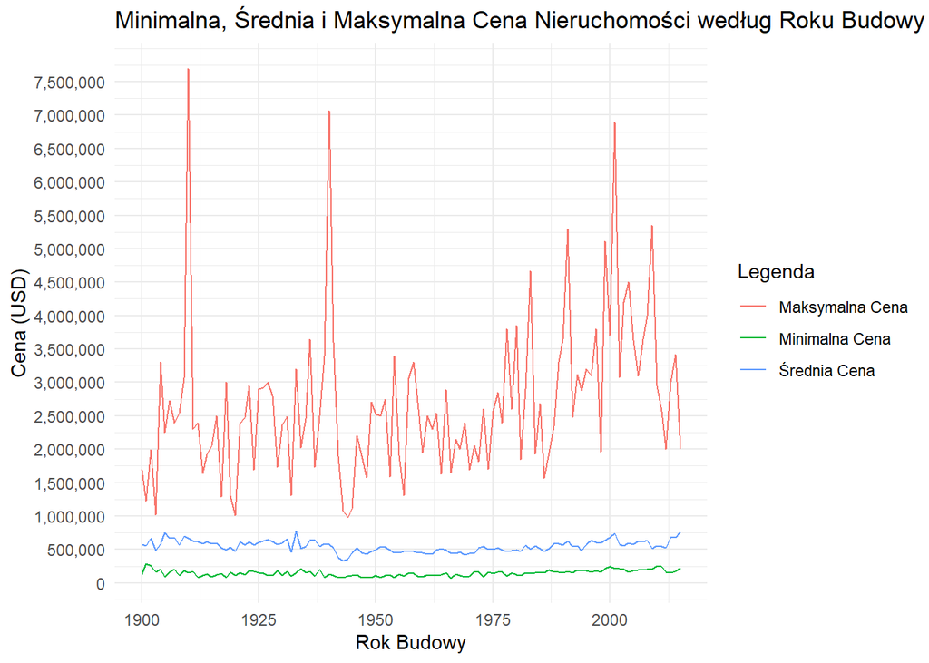

```r
wynik <- df %>%
  group_by(yr_built) %>%
  summarise(
    min_cena = min(price, na.rm = TRUE),
    srednia_cena = mean(price, na.rm = TRUE),
    max_cena = max(price, na.rm = TRUE)
  )

ggplot(wynik, aes(x = yr_built)) +
  geom_line(aes(y = min_cena, color = "Minimalna Cena")) +
  geom_line(aes(y = srednia_cena, color = "Średnia Cena")) +
  geom_line(aes(y = max_cena, color = "Maksymalna Cena")) +
  labs(title = "Minimalna, Średnia i Maksymalna Cena Nieruchomości według Roku Budowy",
       x = "Rok Budowy",
       y = "Cena (USD)",
       color = "Legenda") +
  scale_y_continuous(labels = function(x) format(x, big.mark = ",", scientific = FALSE), breaks = seq(0, max(df$price, na.rm = TRUE), by = 500000))+
  theme_minimal()
```

```r
# library(tidyr)
#
# wynik <- df %>%
#   group_by(yr_built) %>%
#   summarise(
#     min_cena = min(price, na.rm = TRUE),
#     srednia_cena = mean(price, na.rm = TRUE),
#     max_cena = max(price, na.rm = TRUE)
#   )
#
# # Przekształcamy dane do formatu długiego, aby można było użyć facetingu
# wynik_long <- wynik %>%
#   pivot_longer(cols = c(min_cena, srednia_cena, max_cena),
#                names_to = "typ_ceny",
#                values_to = "cena")
#
# # Tworzymy wykres z użyciem facet_grid
# ggplot(wynik_long, aes(x = yr_built, y = cena)) +
#   geom_line() +
#   facet_grid(rows = vars(typ_ceny), scales = "free_y") +
#   labs(title = "Minimalna, Średnia i Maksymalna Cena Nieruchomości według Roku Budowy",
#        x = "Rok Budowy",
#        y = "Cena (USD)") +
#   theme_minimal()
```

**Komentarz: Na wykresie widzimy, że maksymalna cena zmienia się drastycznie względem roku budowy nieruchomości, jednak minimalna i średnia oscylują przy tych samych wartościach.**